# Homework 01

Austin Dollar

8/28/2021

## Dataset Description and where to find

The data set that I used for this assignment is called “AirPassengers.” This is an included data set with R, inside the package ‘data sets.’ The AirPassengers data set records monthly air passenger numbers from the year 1949 until 1960. While a rather simple data set, it is really interesting to look at, as is gives distinct trends, which are especially visible on the included graphical representation below.

## Plotted Data

Below is the Airpassengers data set plotted into a graphical representation:

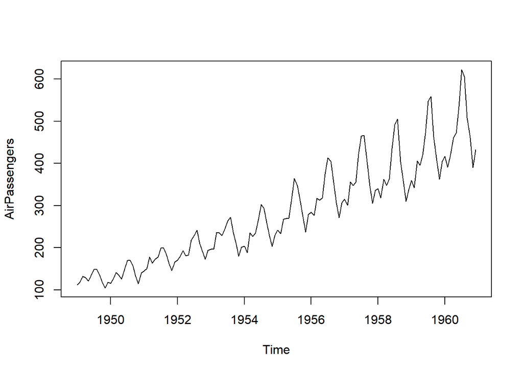

```r
plot(AirPassengers)
```

This is a really interesting graph to look at, as it suggests peak travel time in the summer months, with a steady increase in overall passengers over time.

## Data Summary Statistics

Below is a summary of the data contained in the AirPassengers data set. Detailed descriptions of each statistic are included below the summary:

```r
summary(AirPassengers)
```

```
##    Min. 1st Qu.  Median    Mean 3rd Qu.    Max.
##   104.0   180.0   265.5   280.3   360.5   622.0
```

Above is the General Summary Statistics for the AirPassengers data set. This data shows us a lot, but the most interesting is that of the median and the mean. These values are extremely close together, relative to the overall values in the data set. This suggests to us that there is an overall even distribution of values across the measurement period, which suggests a somewhat linear trend.

```r
sd(AirPassengers)
```

```
## [1] 119.9663
```

Above is the Calculated Standard Deviation for this data set. The standard deviation in this case is relatively high. This tells us that our values are changing in a trend, meaning, they do not stay stagnant.

```r
IQR(AirPassengers)
```

```
## [1] 180.5
```